# Chapter 24: Inference for linear regression, continued

# Overview

- 24.4 Mathematical model for testing the slope
  - 24.4.1 Observed data
  - 24.4.2 Variability of the statistic
  - 24.4.3 Observed statistic vs. null statistics
- 24.5 Mathematical model, interval for the slope
  - 24.5.1 Observed data
  - 24.5.2 Variability of the statistic
- 24.6 Checking model conditions
  - 24.6.1 What are the technical conditions for the mathematical model?
  - 24.6.2 Why do we need technical conditions?
  - 24.6.3 What if all the technical conditions are not met?

# Last time: regression inference

- Linear regression model: $y = \beta_0 + \beta_1x + \varepsilon$
- Regression equation: $\hat{y} = b_0 + b_1x$
- $b_0$ and $b_1$ are *statistics*.
  - $b_0$ is our best guess for the parameter $\beta_0$
  - $b_1$ is our best guess for the parameter $\beta_1$
- Null Hypothesis: No linear association
  - $H_0: \beta_1 = 0$
    - Regression slope is zero
  - $H_A: \beta_1 \neq 0$
    - Some linear association

## Randomization test for regression slope

- You have $n$ observations of two numeric variables, explanatory and response.
- Write the values of the response variable on $n$ cards.
- Shuffle, then randomly pair up with values of the explanatory variable.
- Compute a shuffled $b_1$. (lots)
- Make a null distribution.
- Get a p-value.

# 24.4 Mathematical model for testing the slope

- We can get a $T$-statistic from the *correlation coefficient* $r$.
- Alternatively, we can get a $T$ statistic if we know the *standard error* of $b_1$.
- This will have a $t$-distribution with $n-2$ degrees of freedom.
- Usually we will use software to get the $t$-statistic and P-value.

$$T = \frac{r}{\sqrt{\frac{1-r^2}{n-2}}} = \frac{b_1 - 0}{SE_{b_1}}$$

## 24.4.1 Observed data

- Midterm elections from 1898 to 2018.
- Explanatory: unemployment rate
- Response: percent change in House for president’s party

**Research Question:** Can the unemployment rate predict how the president’s party will do in the midterm elections?

## House-Midterms data set

```r
glimpse(midterms_house)
```

```
Rows: 31
Columns: 5
$ year         <int> 1899, 1903, 1907, 1911, 1915, 1919, 1923, 1927, 1931, 1935, 1939, 1943, 1947,…
$ potus        <fct> William McKinley, Theodore Roosevelt, Theodore Roosevelt, William Howard Taft…
$ party        <fct> Republican, Republican, Republican, Republican, Democrat, Democrat, Republica…
$ unemp        <dbl> 11.62, 4.30, 3.29, 5.86, 6.63, 3.38, 6.93, 4.02, 8.94, 21.30, 17.80, 4.70, 3.…
$ house_change <dbl> -9.223301, -4.275907, -12.291499, -26.590640, -20.962199, -10.280374, -25.496…
```

## Scatterplot and Regression Line

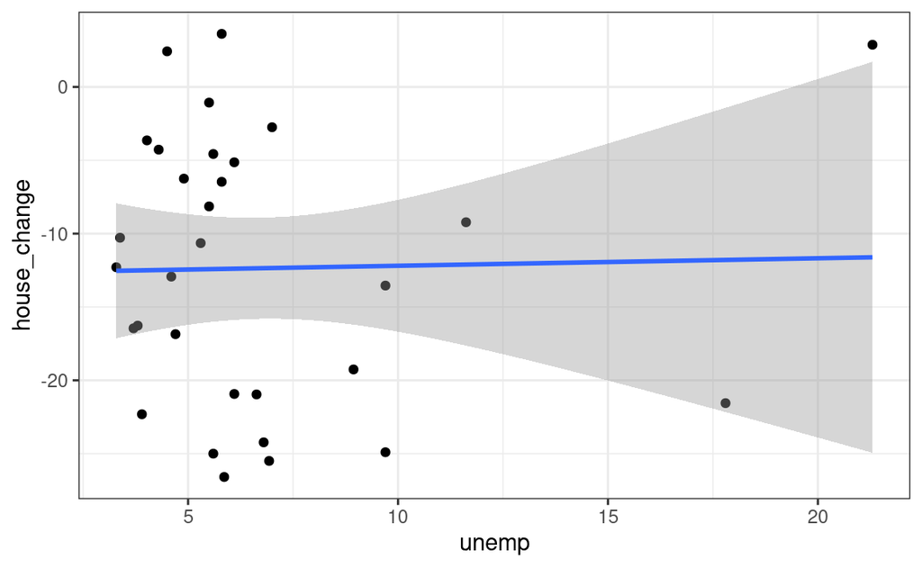

```r
ggplot(midterms_house, aes(x=unemp, y=house_change)) +
  geom_point() +
  geom_smooth(method=lm)
```

## Group Discussion: Outliers

1. Do any observations stand out as *influential* outliers?
2. Guess when these observations took place.

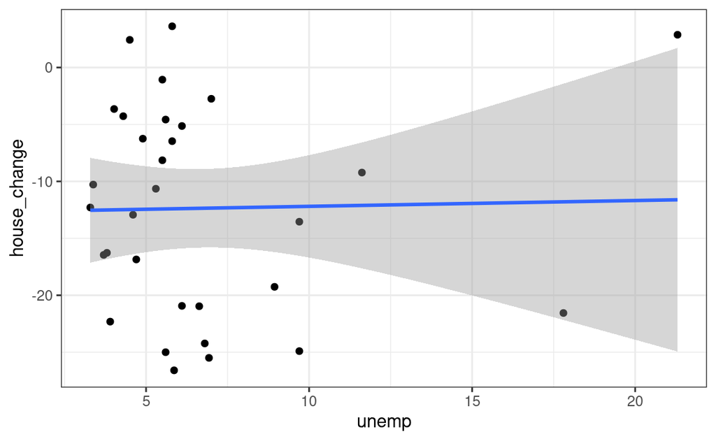

## Use filter

```r
midterms_house %>% filter(unemp > 15)
```

```
# A tibble: 2 × 5
   year potus                     party    unemp house_change
  <int> <fct>                     <fct>    <dbl>        <dbl>
1  1935 Franklin Delano Roosevelt Democrat  21.3         2.88
2  1939 Franklin Delano Roosevelt Democrat  17.8       -21.6
```

## Remove outliers and replot

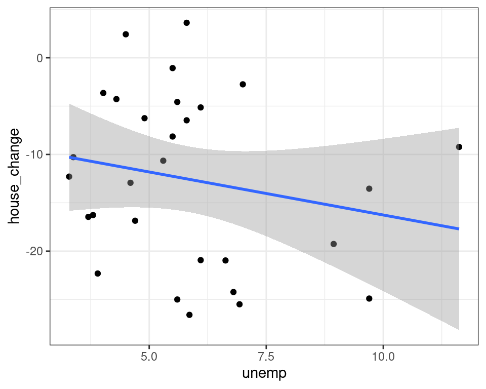

```r
midhouse_nodep <- midterms_house %>% filter(unemp < 15)
ggplot(midhouse_nodep, aes(x=unemp, y=house_change)) +
  geom_point() +
  geom_smooth(method=lm)
```

## 24.4.2 Variability of the statistic

```r
summary(lm(house_change ~ unemp, data = midhouse_nodep))
```

```
Call:
lm(formula = house_change ~ unemp, data = midhouse_nodep)

Residuals:
     Min       1Q   Median       3Q      Max
-14.0124  -7.6989   0.0913   7.2974  16.1447

Coefficients:
            Estimate Std. Error t value Pr(>|t|)
(Intercept)  -7.3644     5.1553  -1.429    0.165
unemp        -0.8897     0.8350  -1.066    0.296

Residual standard error: 8.913 on 27 degrees of freedom
Multiple R-squared:  0.04035,   Adjusted R-squared:  0.004812
F-statistic: 1.135 on 1 and 27 DF,  p-value: 0.2961
```

The data do not show much evidence that unemployment rate is associated with gains/losses in the midterm elections.

# Breakfast Cereal Ratings

Several variables were recorded on 74 different breakfast cereals: number of calories per serving, grams of protein, grams of fat, milligrams of sodium, grams of fiber, grams of carbohydrates, grams of sugars, milligrams of potassium, typical percentage of the FDA’s RDA of vitamins, the weight of one serving, the number of cups in one serving, and the shelf location (1,2 or 3 for bottom, middle or top). A variable named “rating” was calculated by Consumer Reports.

## Sugar and Cereal Rating

Is there a linear relationship between the sugar content of a cereal and its rating?

- Null Hypothesis: There is no association between sugar content and rating.
  - $H_0: \beta_1 = 0$
- Alternative Hypothesis: There is a linear relationship between between sugar content and rating.
  - $H_A: \beta_1 \neq 0$

## Group Activity

1. Paste the [CerealSugar](http://math.westmont.edu/data/cerealsugar.txt) data into the [Applet](http://www.rossmanchance.com/applets/RegShuffle.htm?hideExtras=2) and record the correlation coefficient $r$.
2. Find the $T$-statistic using the following formula.
   $$T = \frac{r}{\sqrt{\frac{1-r^2}{n-2}}}$$
3. Run a simulation with 1000 shuffles. Select *t-statistic*, then check the *Overlay t distribution* button. Does the t-distribution appear to do a good job of predicting the distribution of the simulated t-statistics?
4. In the applet, click the box for *Regression Table*. This table provides the observed $T$-statistic for the data as well as the two-sided, theory-based test P-value. Compare the $T$-statistic to the value you calculated in #2. Record the P-value, along with an interpretation of its meaning in context.

## Regression table using R

```r
cerealsugar <- read.table("http://math.westmont.edu/data/cerealsugar.txt", header = TRUE)
summary(lm(rating ~ sugars, data = cerealsugar))
```

```
Call:
lm(formula = rating ~ sugars, data = cerealsugar)

Residuals:
    Min      1Q  Median      3Q     Max
-17.944  -5.596  -1.380   4.773  34.034

Coefficients:
            Estimate Std. Error t value Pr(>|t|)
(Intercept)  59.6709     2.0672  28.866  < 2e-16 ***
sugars       -2.4337     0.2484  -9.799 6.92e-15 ***
---
Signif. codes:  0 '***' 0.001 '**' 0.01 '*' 0.05 '.' 0.1 ' ' 1

Residual standard error: 9.25 on 72 degrees of freedom
Multiple R-squared:  0.5715,    Adjusted R-squared:  0.5655
F-statistic: 96.02 on 1 and 72 DF,  p-value: 6.924e-15
```

# 24.5 Mathematical model, interval for the slope

## 24.5.1 Observed data

You need:

- The point estimate $b_1$
- The standard error $SE$
  - Usually you use software to get this.
- $t^\star_{df}$
  - $df = n - 2$
  - The confidence level determines the tail probabilities.

$$\text{point estimate} \pm t^\star_{df} \times SE$$

## Example: College Gift Aid

```r
glimpse(elmhurst)
```

```
Rows: 50
Columns: 3
$ family_income <dbl> 92.922, 0.250, 53.092, 50.200, 137.613, 47.957, 113.534, 168.579, 208.115, 1…
$ gift_aid      <dbl> 21.720, 27.470, 27.750, 27.220, 18.000, 18.520, 13.000, 13.000, 14.000, 25.4…
$ price_paid    <dbl> 14.280, 8.530, 14.250, 8.780, 24.000, 23.480, 23.000, 29.000, 28.000, 16.530…
```

## Scatterplot and Regression Line

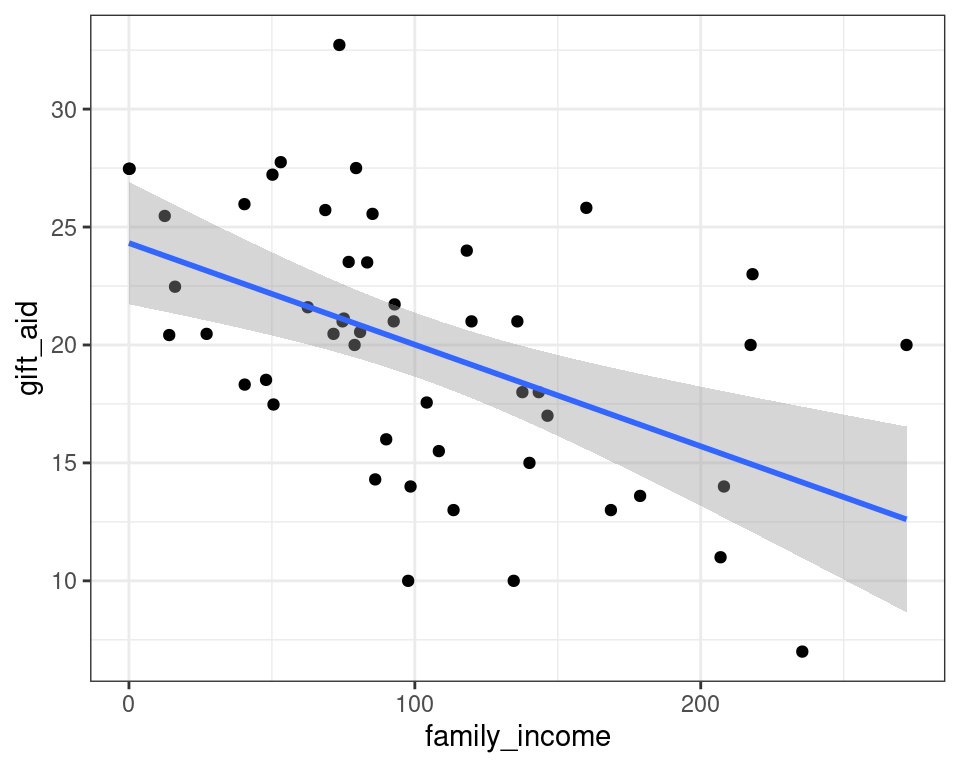

```r
ggplot(elmhurst, aes(x=family_income, y=gift_aid)) +
  geom_point() +
  geom_smooth(method=lm)
```

## Regression Model

```r
summary(lm(gift_aid ~ family_income, data = elmhurst))
```

```
Call:
lm(formula = gift_aid ~ family_income, data = elmhurst)

Residuals:
     Min       1Q   Median       3Q      Max
-10.1128  -3.6234  -0.2161   3.1587  11.5707

Coefficients:
              Estimate Std. Error t value Pr(>|t|)
(Intercept)   24.31933    1.29145  18.831  < 2e-16 ***
family_income -0.04307    0.01081  -3.985 0.000229 ***
---
Signif. codes:  0 '***' 0.001 '**' 0.01 '*' 0.05 '.' 0.1 ' ' 1

Residual standard error: 4.783 on 48 degrees of freedom
Multiple R-squared:  0.2486,    Adjusted R-squared:  0.2329
F-statistic: 15.88 on 1 and 48 DF,  p-value: 0.0002289
```

## Compute a confidence interval

```
                 Estimate Std. Error   t value     Pr(>|t|)
(Intercept)   24.31932901 1.29145027 18.831022 8.281020e-24
family_income -0.04307165 0.01080947 -3.984621 2.288734e-04
```

- $SE_{b_1} \approx 0.0108$
- $df = 48$
- $b_1 \approx -0.0431$
- To obtain $t^\star_{48}$, we have to use `qt`. We want a 95% confidence interval.

```r
qt(0.975, df = 48)
```

```
[1] 2.010635
```

95% CI for $\beta_1$: $-0.0431 \pm 2.01 \times 0.0108 \approx (-0.0648, -0.0214)$

## Group Activity

Recall the regression model for predicting cereal rating (in points) from sugar content (in grams).

```
            Estimate Std. Error  t value     Pr(>|t|)
(Intercept) 59.67093  2.0671567 28.86619 2.567096e-41
sugars      -2.43372  0.2483705 -9.79875 6.924141e-15
```

1. Compute a 90% confidence interval for the regression slope.
2. Write a sentence interpreting this confidence interval in the context of the study.

# 24.6 Checking model conditions

- Every mathematical model is based on theorems that assume that our data has certain properties.
- The P-values and confidence intervals that we compute using mathematical models are not guaranteed to be correct unless these conditions are met.

## 24.6.1 What are the technical conditions for the mathematical model?

- **Linearity.** The data should show a linear trend.
- **Independent observations.** The ordered pairs describe independent observations (e.g., from a random sample).
- **Nearly normal residuals.** Generally, the residuals must be nearly normal.
- **Constant or equal variability.** The variability of points around the least squares line remains roughly constant.

## Plotting residuals versus fitted

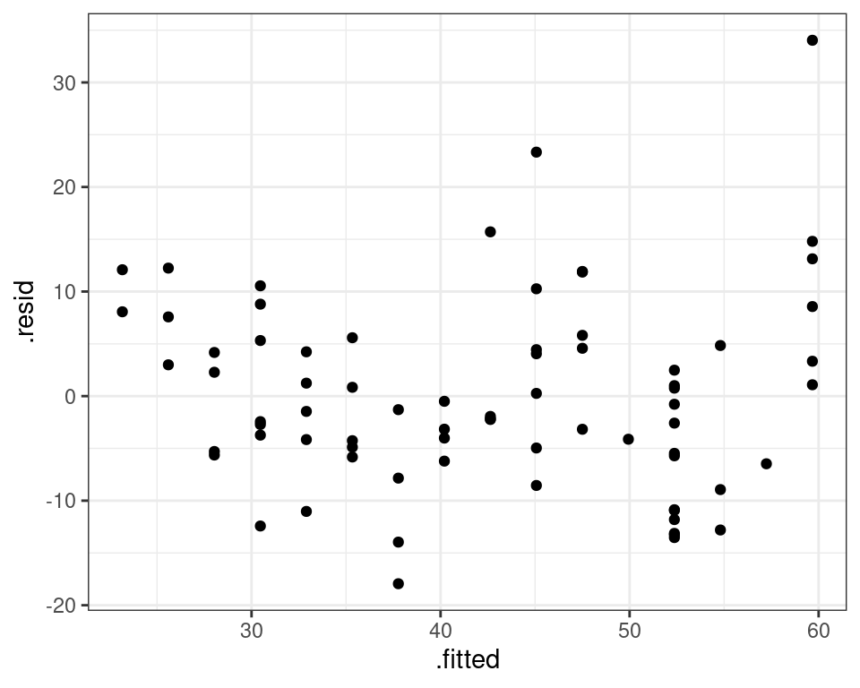

```r
cerealmodel <- lm(rating ~ sugars, data = cerealsugar)
ggplot(cerealmodel, aes(x = .fitted, y = .resid)) + geom_point()
```

## More diagnostic plots

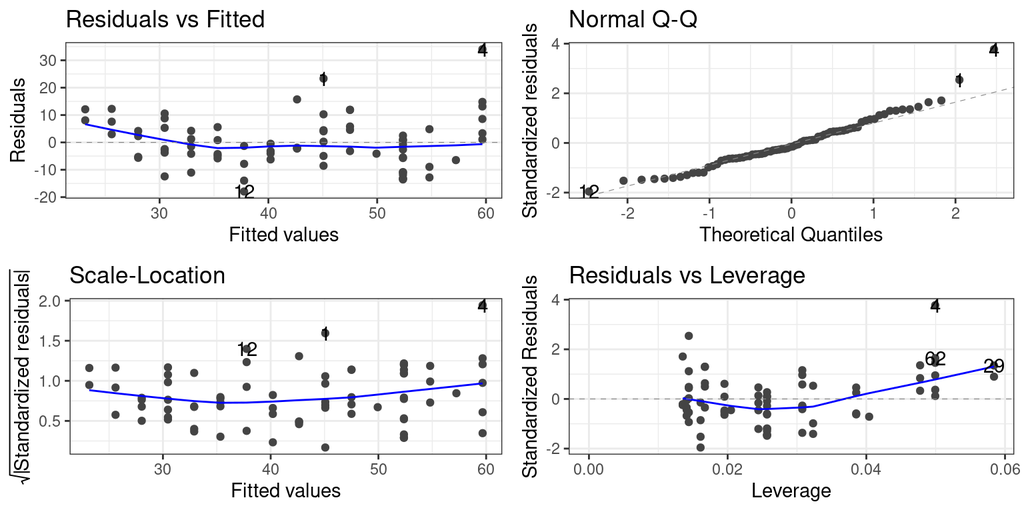

```r
library(ggfortify)
autoplot(cerealmodel)
```

## Failures to meet the conditions

- Data is *not symmetric* above and below the line:

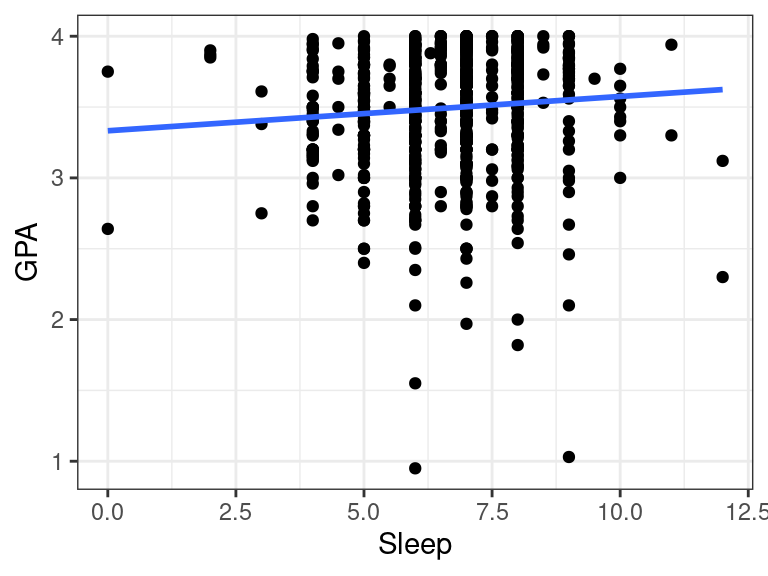

- Data doesn’t follow a linear pattern:

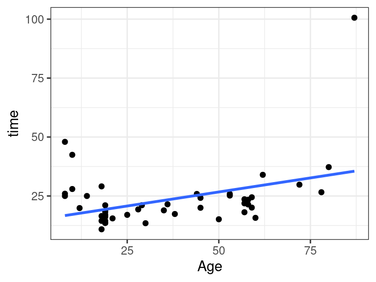

## More Failures

Variability of vertical slices changes (heteroscedasticity):

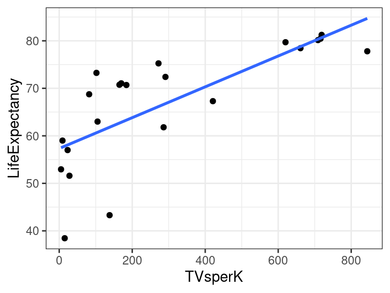

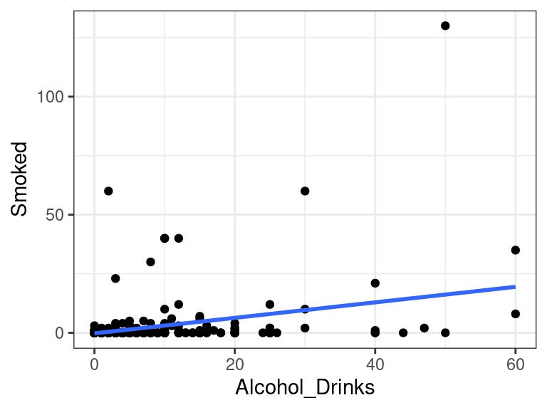

## What to do when conditions fail

- What do you do when validity conditions aren’t met for theory-based inference?
  - If it’s not too bad, the theory-based tests are probably OK
  - Use the simulation-based approach…
    - *instead of* the theory-based test, for really bad failures
    - or *in addition to* the theory-based test, in borderline cases
- Another strategy is to “transform” the data on a different scale so conditions are met.
  - The logarithmic scale is common